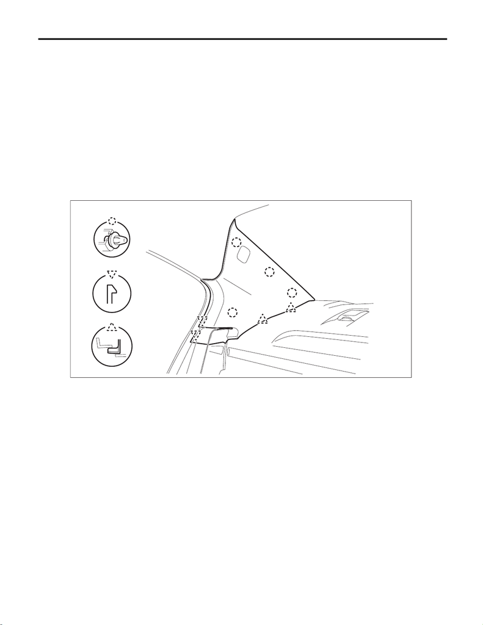

EI-89

Rear Quarter Trim

EXTERIOR/INTERIOR TRIM

25.Rear Quarter Trim

A: REMOVAL

CAUTION:

• Airbag system satellite safing sensor is located in the lower of the rear seat cushion center. Before

removing the rear seat, refer to “CAUTION” of “General Description” in “AIRBAG SYSTEM” section.

<Ref. to AB-9, CAUTION, General Description.>

• The airbag system is fitted with a backup power supply. After disconnecting the battery ground ca-

ble, the airbag may operate if you do not wait for 60 seconds before starting the service of airbag sys-

tem.

1) Disconnect the ground cable from battery and wait for at least 60 seconds before starting work. <Ref. to

NT-5, BATTERY, NOTE, Note.>

NOTE:

For models other than STI model, disconnect the ground terminal from battery sensor.

2) Remove the clips, and remove the trim panel - rear pillar UPR.

3) Remove the rear seat cushion assembly. <Ref. to SE-29, REMOVAL, Rear Seat.>

EI-03455

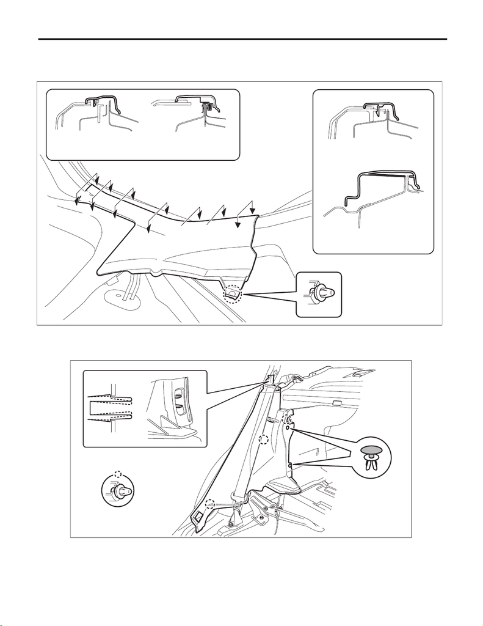

EI-90

Rear Quarter Trim

EXTERIOR/INTERIOR TRIM

4) Release the clips and claws, and then remove the cover side sill - rear INN.

CAUTION:

Do not pull with excessive force. Doing so may damage the claws of the cover side sill - rear INN.

5) Remove the trim panel - rear pillar LWR.

(1) Remove the clips, and turn over the trim panel - trunk side.

(2) Remove the clips, and remove the trim panel - rear pillar LWR.

EI-03497

A

A

B

B

C-C

D-D

D

D

C

C

C

C

B

B

A-A

B-B

EI-04329

[figure not shown]

EI-91

Rear Quarter Trim

EXTERIOR/INTERIOR TRIM

B: INSTALLATION

1) Install the trim panel - rear pillar LWR.

2) Install the cover side sill - rear INN.

3) Install the rear seat cushion assembly.

4) Install the trim panel - rear pillar UPR.

5) Connect the battery ground terminal. <Ref. to NT-5, BATTERY, NOTE, Note.>

NOTE:

For models other than STI model, connect the ground terminal to battery sensor.